# Figures

The seven manuscript figures, with what each one claims

Each figure below is the plate as it appears in the manuscript. The claim is stated in a sentence or two; the statistics behind it, and the caveats that go with them, live in the paper rather than here.

**Important**

There is no ground-truth Tpex label in human tumors. Every comparison here is between annotations, not between an annotation and a known answer. That is the point of the study, and it is also the limit on every claim in it.

## Figure 1: Characterization of the three CD8 reference atlases

**What the three CD8 reference atlases are, before any query cohort is annotated.**

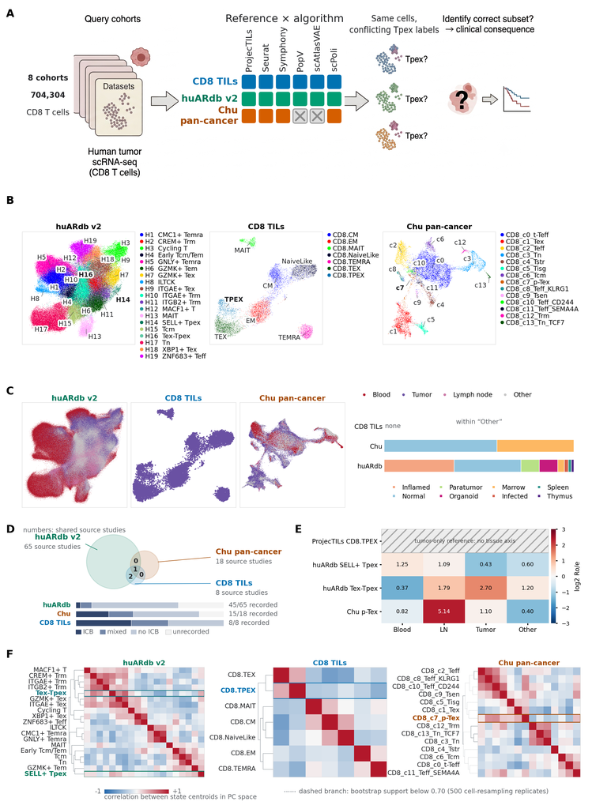

The three reference atlases used throughout differ in what they contain, where their cells came from, and how they were built, before a single query cell is labelled. Everything that follows is downstream of these differences rather than of the annotation software.

## Figure 2: Tpex definitions and their expression profiles across atlases

**What each reference atlas calls Tpex, and what those cells express.**

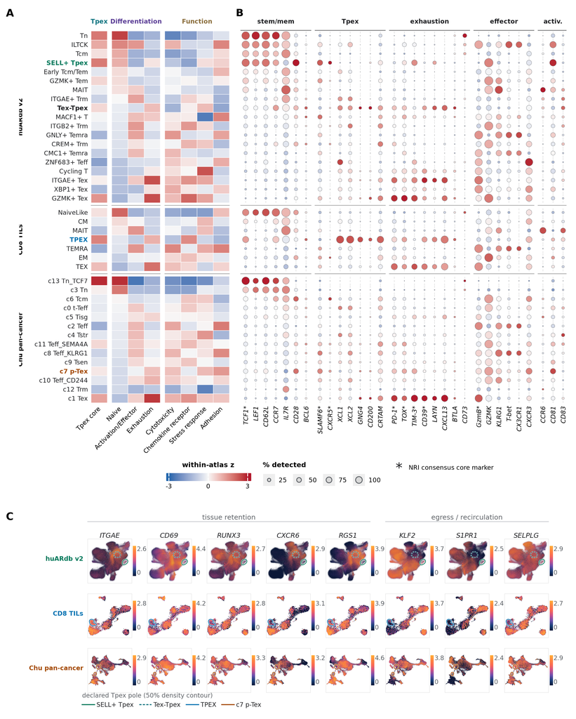

## Figure 3: Clonal adjudication of the two huARdb Tpex poles

**huARdb’s two Tpex poles judged clonally, where the receptor and the transcriptome disagree about which one is the progenitor.**

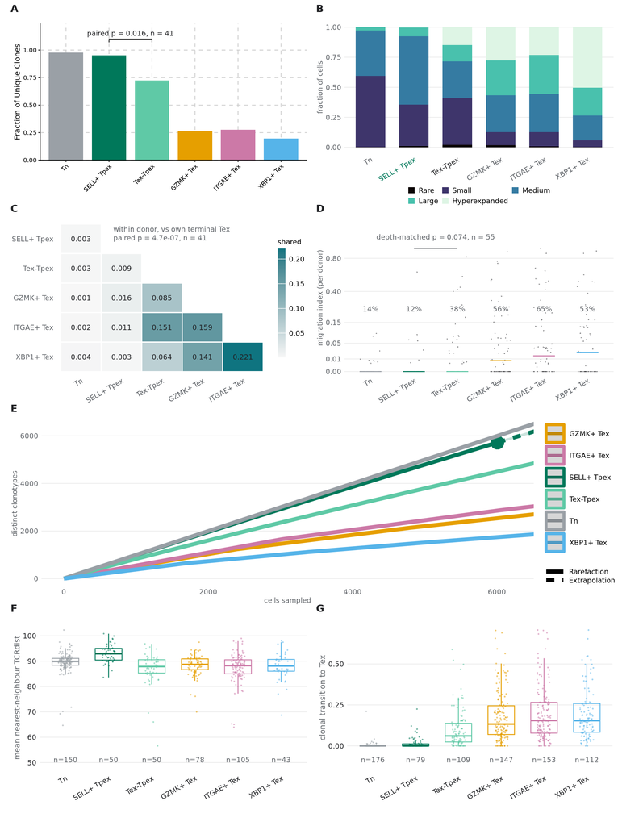

One reference names two progenitor poles of its own. Judged by T-cell receptor sharing rather than by expression, the pole that looks most stem-like transcriptionally is the one least connected to the expanded exhausted lineage.

## Figure 4: Shared progenitor core and divergence between reference Tpex definitions

**The references share a small progenitor core, diverge beyond it, and pair across atlases rather than within one.**

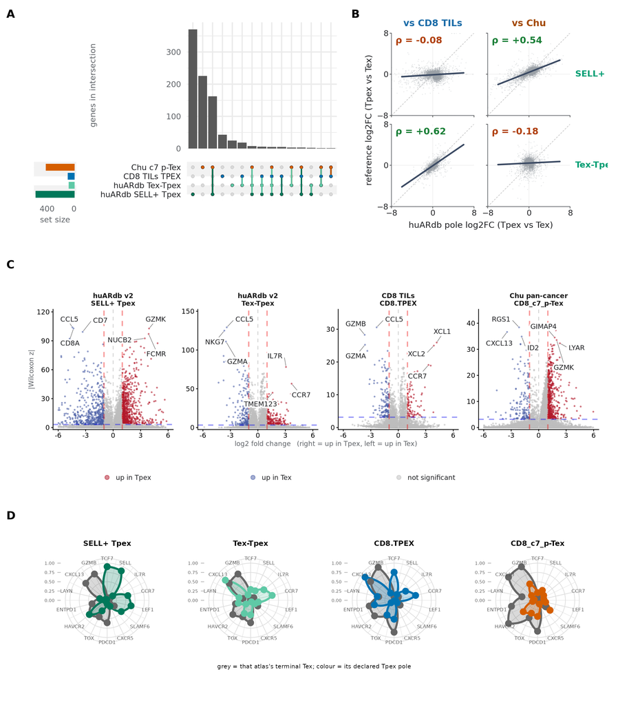

A narrow set of progenitor genes is common to all three references. Past that core the definitions separate, and the labels that most resemble one another sit in *different* atlases rather than in the same one.

## Figure 5: Recovery of author-defined Tpex by each reference atlas

**Reference atlases place their Tpex label on cells the query authors called something else, and the four definitions differ from each other in programme, in composition and in continuum position.**

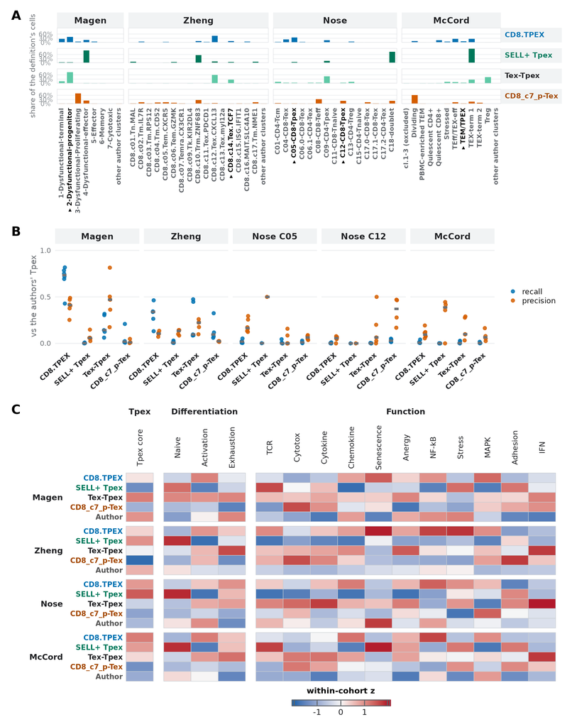

When a reference annotates a published cohort, its Tpex call frequently lands on cells the original authors assigned to a different state. The four progenitor definitions then differ from one another on every axis measured here.

## Figure 6: Reference versus algorithm contribution to the Tpex call, and label reproducibility

**The reference atlas decides which cells are called Tpex, and whether the label is reproducible at all.**

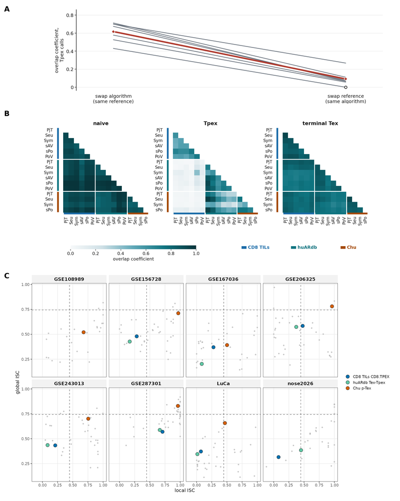

Holding the reference fixed and changing the annotation algorithm preserves most of the Tpex call; holding the algorithm fixed and changing the reference does not, in every cohort tested. For one of the three references the progenitor label is the least reproducible label between patients that its own vocabulary names, and it is near-worst in a second.

## Figure 7: Compositional and clinical consequences of the annotation choice

**Swapping the annotation loses a published clinical result.**

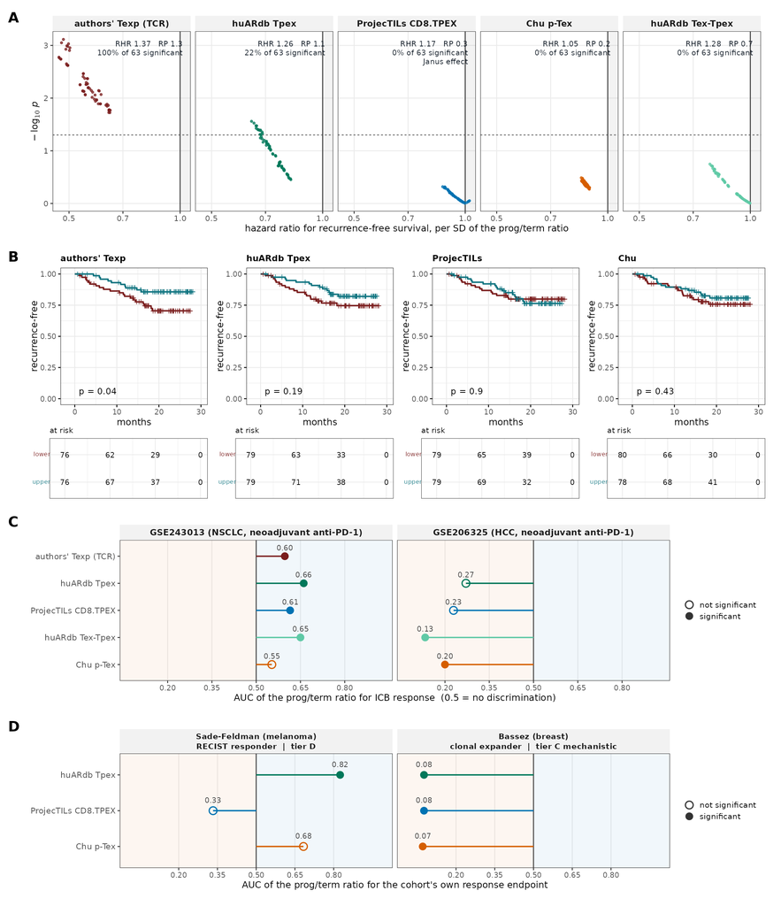